# 왜 진보는 가난해야 하는가? : 이광수의 ‘진보를 위한 주식투자’

경제

투자

투자를 주권 행위로 재정의한 이광수 작가의 투자 철학. ’왜 진보는 가난해야 하는가’라는 화두를 통해 경제적 민주주의와 진보적 투자의 길을 탐구합니다.

Published

April 28, 2026

[figure not shown]

왜 진보는 가난해야 하는가? : 이광수의 ‘진보를 위한 주식투자’

**“왜 진보는 가난해야 하는가?”**

이 도발적인 질문은 이광수 작가가 우리 사회에 던지는 묵직한 화두입니다. 우리는 흔히 ’진보’라고 하면 자본주의에 비판적이고, 소박한 삶을 지향하며, 자본 시장과는 거리가 먼 이미지를 떠올리곤 합니다. 하지만 이광수 작가는 정반대로 말합니다. 진보적인 가치를 지키고 세상을 더 나은 방향으로 바꾸고 싶을수록, 우리는 자본을 이해하고 주식 시장에 참여해야 한다고 말이죠. 오늘은 투자라는 행위를 ’주권자의 참여’로 재정의한 독보적인 투자서, **《진보를 위한 주식투자》**를 살펴보겠습니다.

### 핵심 요약: 투자는 돈이 아닌 세상을 버는 행위

1. **투자는 주권 행위다**: 투자는 단순히 시세 차익을 노리는 도박이 아니라, 기업의 의사결정에 참여하고 사회적 자원을 배분하는 민주주의적 권리입니다.
2. **기업의 지배구조와 투명성**: 기업의 이익이 주주에게 올바르게 환원되는 ’경제적 정의’가 실현될 때 자본주의는 진보합니다.
3. **성장에 투자하라**: 혁신을 통해 세상을 이롭게 만드는 기업을 찾아내고 그 성장에 동참하는 것이 진정한 가치 투자입니다.

### 상세 분석: 자본가로서의 주권자를 꿈꾸다

#### 1. 자본주의 시스템 안에서의 진보적 삶

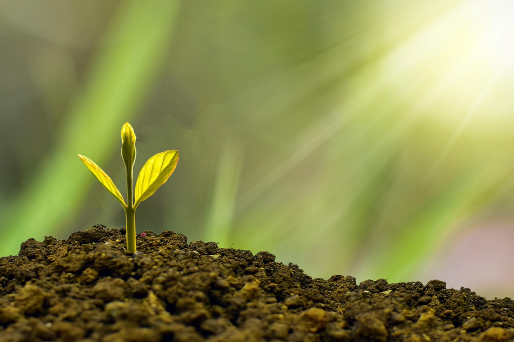

자본의 성장이 곧 사회의 진보로 이어지는 길

이 책은 투자 기술을 가르치기 전에 ’투자자의 태도’를 묻습니다. 많은 진보적 인사들이 자본 시장을 탐욕의 공간으로만 치부하며 외면할 때, 실제 세상의 부는 왜곡된 방식으로 소수에게 집중되었습니다. 작가는 묻습니다. **“왜 진보는 가난해야 하는가?”** 우리가 시장을 외면하는 동안 기업의 지배구조는 불투명해졌고 주주의 권리는 무시되었습니다. 이제는 진보적 가치를 가진 이들이 적극적으로 주식을 소유함으로써, 기업이 사회적 책임을 다하고 이익을 공정하게 나누도록 감시하고 참여해야 합니다.

#### 2. 주권자로서의 투자와 경제 민주주의

[figure not shown]

이광수 작가가 강조하는 투자의 핵심은 ’거버넌스(지배구조)’입니다. 대한민국 주식 시장이 저평가받는 ’코리아 디스카운트’의 원인을 그는 불투명한 기업 운영과 주주 경시 풍조에서 찾습니다. 투자자가 단순히 가격 변동에 일희일비하는 ’매매자’가 아니라, 기업의 주인으로서 제 목소리를 내는 ’주주’가 될 때 시장의 체질이 바뀝니다. 이것이 바로 투자를 통한 경제적 민주주의의 실현입니다.

#### 3. 미래의 가치와 성장에 집중하는 통찰

[figure not shown]

지속적인 학습과 리서치를 통한 통찰의 시간

알라딘과 교보문고의 수많은 독자가 이 책에 열광한 이유는 ’공부하는 투자’의 즐거움을 일깨워주기 때문입니다. 작가는 차트를 보는 기술보다 세상을 읽는 리서치를 강조합니다. 어떤 기술이 인류의 삶을 개선하고 있는가? 어떤 기업이 그 변화를 주도하고 있는가? 이러한 질문에 답을 찾아가는 과정 자체가 진보적인 투자자가 걸어가야 할 길입니다. 세상을 이롭게 하는 성장에 내 자본을 보태고 그 결실을 함께 나누는 것, 그것이 이 책이 말하는 ’진보적 투자’의 완성입니다.

### 마무리: 당신의 자본에는 어떤 의지가 담겨 있습니까?

투자는 투표와 같습니다. 내가 산 주식 한 주에는 ’이런 기업이 우리 사회에 더 많아졌으면 좋겠다’는 지지와 응원이 담겨 있어야 합니다. 돈을 버는 것은 그 올바른 선택에 따라오는 자연스러운 결과일 뿐입니다.

더 이상 **“왜 진보는 가난해야 하는가”**라는 질문에 고개를 숙이지 마세요. 여러분의 투자가 기업을 투명하게 만들고, 혁신을 응원하며, 사회적 부를 공정하게 나누는 강력한 도구가 되길 바랍니다. 오늘부터 당신도 세상을 바꾸는 ’주권자 투자자’로 거듭나보는 건 어떨까요?

#이광수 #진보를위한주식투자 #주식투자철학 #경제적자유 #가치투자 #책리뷰 #경제민주주의 #베스트셀러 #재테크독서 #주권자투자